# Evidencia_2

Sebastián Iñigo

2022-05-05

Parte 1 Link del video

https://youtu.be/yz8x5Z1E3FQ

Parte 2

```r
library(Biostrings)
library(seqinr)
library(adegenet)
library(ape)
library(ggtree)
library(DECIPHER)
library(viridis)
library(ggplot2)
```

```r
PAISES <- c(  "ON402869", "ON148312", "OL989073", "MT470219", "ON148330", "ON365977", "OW443684", " OW518845", "ON380441", "OL989065", "OL989058", "OM758316", "MZ047082", "ON248600", "OM692350", "MW340907", "MT192772", "ON376063", "MZ359830", "OL869974")

paises_sequences <- read.GenBank(PAISES)

str(paises_sequences)
```

```
## List of 20
##  $ ON402869 : raw [1:29803] 18 28 18 28 ...
##  $ ON148312 : raw [1:29843] 48 18 88 88 ...
##  $ OL989073 : raw [1:29903] 88 18 18 88 ...
##  $ MT470219 : raw [1:29903] 88 18 18 88 ...
##  $ ON148330 : raw [1:29764] 88 18 18 88 ...
##  $ ON365977 : raw [1:29766] 28 18 18 18 ...
##  $ OW443684 : raw [1:29889] 48 88 18 18 ...
##  $  OW518845: raw [1:29873] f0 f0 f0 f0 ...
##  $ ON380441 : raw [1:29785] 48 88 18 28 ...
##  $ OL989065 : raw [1:29903] 88 18 18 88 ...
##  $ OL989058 : raw [1:29903] 88 18 18 88 ...
##  $ OM758316 : raw [1:29833] 28 88 88 88 ...
##  $ MZ047082 : raw [1:29884] 88 18 18 88 ...
##  $ ON248600 : raw [1:29816] 88 88 28 88 ...
##  $ OM692350 : raw [1:29848] 88 18 88 28 ...
##  $ MW340907 : raw [1:29813] 28 88 88 28 ...
##  $ MT192772 : raw [1:29891] 88 18 18 88 ...
##  $ ON376063 : raw [1:29747] 18 18 48 18 ...
##  $ MZ359830 : raw [1:29800] 28 18 48 18 ...
##  $ OL869974 : raw [1:29705] 88 18 28 18 ...
##  - attr(*, "class")= chr "DNAbin"
##  - attr(*, "description")= chr [1:20] "ON402869.1 Severe acute respiratory syndrome coronavirus 2 isolate SARS-CoV-2/human/USA/MA-Broad-CRSP_2OIBBVZWR"| __truncated__ "ON148312.1 Severe acute respiratory syndrome coronavirus 2 isolate SARS-CoV-2/human/BRA/GO-DNAGYN-218/2021, complete genome" "OL9…
##  - attr(*, "species")= chr [1:20] "Severe_acute_respiratory_syndrome_coronavirus_2" "Severe_acute_respiratory_syndrome_coronavirus_2" "Severe_acute_respiratory_syndrome_coronavirus_2" "Severe_acute_respiratory_syndrome_coronavirus_2" ...
```

```r
write.dna(paises_sequences,
          file ="paises_seqs.fasta",
          format = "fasta",
          append = FALSE,
          nbcol = 6,
          colsep = " ",
          colw = 10)

paises_seq_not_align <- readDNAStringSet("paises_seqs.fasta", format = "fasta")
paises_seq_not_align
```

```
## DNAStringSet object of length 20:
##      width seq                                                             names
##  [1] 29803 TCTCTTGTAGATCTGTTCTCTAAACGAACT...AAAAAAAAAAAAAAAAAAAAAAAAAAAAAA ON402869
##  [2] 29843 GTAACAAACCAACCAACTTTCGATCTCTTG...TGATTTTAATAGCTTCATAGGAGAATGNCA ON148312
##  [3] 29903 ATTAAAGGTTTATACCTTCCCAGGTAACAA...AAAAAAAAAAAAAAAAAAAAAAAAAAAAAA OL989073
##  [4] 29903 ATTAAAGGTTTATACCTTCCCAGGTAACAA...AAAAAAAAAAAAAAAAAAAAAAAAAAAAAA MT470219
##  [5] 29764 ATTAAAGGTTTATACCTTCCCAGGTAACAA...TGAACAATGCTAGGGAGAGCTGCCTATATG ON148330
##  ...   ... ...
## [16] 29813 CAACCAACTTTCGATCTCTTGTAGATCTGT...TTAATTTTAGTAGTGCTATCCCCATGTGAT MW340907
## [17] 29891 ATTAAAGGTTTATACCTTCCCAGGTAACAA...GAGAATGACAAAAAAAAAAAAAAAAAAAAA MT192772
## [18] 29747 TTGTAGATCTGTTCTCTAAACGAACTTTAA...GAGCCCTAATGTGTAAAATTAATTTTAGTA ON376063
## [19] 29800 CTGTTCTCTAAACGAACTTTAAAATCTGTG...TGCTATCCCCATGTGATTTTAATAGCTTCT MZ359830
## [20] 29705 ATCTTCTGCAGGCTGCTTACGGTTTCGTCC...AAAAAAAAAAAAAAAAAAAAAAAAAAAAAA OL869974
```

```r
paises_seq_not_align <- OrientNucleotides(paises_seq_not_align)
```

```
##
##
## Time difference of 0.18 secs
```

```r
paises_seq_align <- AlignSeqs(paises_seq_not_align)
```

```
## Determining distance matrix based on shared 11-mers:
##
##
## Time difference of 0.04 secs
##
## Clustering into groups by similarity:
##
##
## Time difference of 0 secs
##
## Aligning Sequences:
##
##
## Time difference of 1.27 secs
##
## Iteration 1 of 2:
##
## Determining distance matrix based on alignment:
##
##
## Time difference of 0.01 secs
##
## Reclustering into groups by similarity:
##
##
## Time difference of 0 secs
##
## Realigning Sequences:
##
##
## Time difference of 1.12 secs
##
## Iteration 2 of 2:
##
## Determining distance matrix based on alignment:
##
##
## Time difference of 0.01 secs
##
## Reclustering into groups by similarity:
##
##
## Time difference of 0 secs
##
## Realigning Sequences:
##
##
## Time difference of 0.01 secs
```

```r
writeXStringSet(virus_seq_align, file="paises_seq_align.fasta")
```

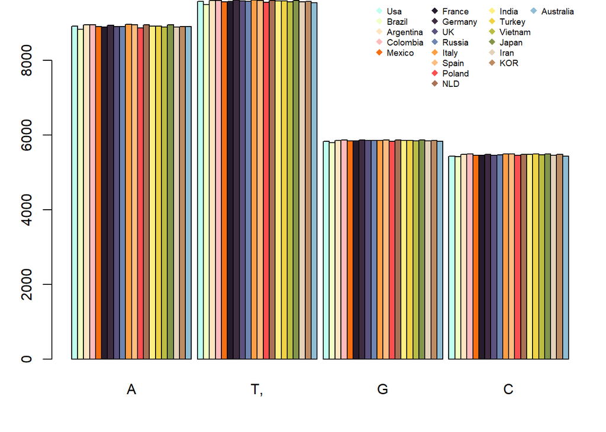

```r
library("seqinr")
paisesfasta<-read.fasta("C:/Users/oso_p/Documents/Oso_Tec/2do_semestre/Analisis_bio/paises_seq_align.fasta")


cuentas <- function(seq){
  contadorA <-0
  contadorT <-0
  contadorC <-0
  contadorG <-0

  nl <- length(seq)

  for(i in seq){

    if(i=="A" || i=="a"){
      contadorA = contadorA + 1
    }
    else if(i=="T" || i=="t") {
      contadorT = contadorT + 1
    }
    else if(i=="C" || i=="c") {
      contadorC = contadorC + 1
    }
    else if(i=="G" || i=="g") {
      contadorG = contadorG + 1
    }
  }

  vec<- c(contadorA,contadorT,contadorG, contadorC)
  return(vec)
}

colorpalette<- c('#BFFFF0', '#F0FFC2', '#FFE4C0', '#FFBBBB','#F76E11','#261C2C', '#3E2C41', '#5C527F', '#6E85B2','#FF9F45','#FFBC80','#FC4F4F','#A97155','#FFEF82', '#EFD345', '#BABD42', '#82954B','#E4D1B9', '#BE8C63','#8FBDD3')

colorpalette1<- c('#BFFFF0', '#F0FFC2', '#FFE4C0', '#FFBBBB','#F76E11')

colorpalette2<- c('#261C2C', '#3E2C41', '#5C527F', '#6E85B2','#FF9F45','#FFBC80','#FC4F4F','#A97155')

colorpalette3<-c('#FFEF82', '#EFD345', '#BABD42', '#82954B','#E4D1B9', '#BE8C63')

colorpalette4<-c('#8FBDD3')


#mundo1<- c("Usa","Brazil", "Argentina", "Colombia", "Mexico","France","Germany","UK","Russia","Italy","Spain", "Poland","NLD","India","Turkey","Vietnam","Japan","Iran","KOR","Australia")

america<-c("Usa","Brazil", "Argentina", "Colombia", "Mexico")
europa<-c("France","Germany","UK","Russia","Italy","Spain", "Poland","NLD")
asia<-c("India","Turkey","Vietnam","Japan","Iran","KOR")
oceania<-c("Australia")

funG<-(paises<-sapply(paisesfasta, cuentas))

par(mar=c(4,3,0,1))
virus<-barplot(matrix(c(funG), nrow=20, byrow=T), beside=T,  col = colorpalette, names.arg= c("A","T,","G", "C"))
legend("topright", legend = america ,
     col = colorpalette1 ,bty = "n", pch=18 , pt.cex = 1, cex = 0.6, horiz = FALSE, inset = c(0.3, 0.001))
legend("topright", legend = europa ,
     col = colorpalette2 ,bty = "n", pch=18 , pt.cex = 1, cex = 0.6, horiz = FALSE, inset = c(0.2, 0.001))
legend("topright", legend = asia ,
     col = colorpalette3 ,bty = "n", pch=18 , pt.cex = 1, cex = 0.6, horiz = FALSE, inset = c(0.1, 0.001))
legend("topright", legend = oceania ,
     col = colorpalette4 ,bty = "n", pch=18 , pt.cex = 1, cex = 0.6, horiz = FALSE, inset = c(0.02, 0.001))
```

```r
PAISES <- c(  "ON402869", "ON148312", "OL989073", "MT470219", "ON148330", "ON365977", "OW443684", " OW518845", "ON380441", "OL989065", "OL989058", "OM758316", "MZ047082", "ON248600", "OM692350", "MW340907", "MT192772", "ON376063", "MZ359830", "OL869974")

virus_sequences <- read.GenBank(PAISES)

str(virus_sequences)
```

```
## List of 20
##  $ ON402869 : raw [1:29803] 18 28 18 28 ...
##  $ ON148312 : raw [1:29843] 48 18 88 88 ...
##  $ OL989073 : raw [1:29903] 88 18 18 88 ...
##  $ MT470219 : raw [1:29903] 88 18 18 88 ...
##  $ ON148330 : raw [1:29764] 88 18 18 88 ...
##  $ ON365977 : raw [1:29766] 28 18 18 18 ...
##  $ OW443684 : raw [1:29889] 48 88 18 18 ...
##  $  OW518845: raw [1:29873] f0 f0 f0 f0 ...
##  $ ON380441 : raw [1:29785] 48 88 18 28 ...
##  $ OL989065 : raw [1:29903] 88 18 18 88 ...
##  $ OL989058 : raw [1:29903] 88 18 18 88 ...
##  $ OM758316 : raw [1:29833] 28 88 88 88 ...
##  $ MZ047082 : raw [1:29884] 88 18 18 88 ...
##  $ ON248600 : raw [1:29816] 88 88 28 88 ...
##  $ OM692350 : raw [1:29848] 88 18 88 28 ...
##  $ MW340907 : raw [1:29813] 28 88 88 28 ...
##  $ MT192772 : raw [1:29891] 88 18 18 88 ...
##  $ ON376063 : raw [1:29747] 18 18 48 18 ...
##  $ MZ359830 : raw [1:29800] 28 18 48 18 ...
##  $ OL869974 : raw [1:29705] 88 18 28 18 ...
##  - attr(*, "class")= chr "DNAbin"
##  - attr(*, "description")= chr [1:20] "ON402869.1 Severe acute respiratory syndrome coronavirus 2 isolate SARS-CoV-2/human/USA/MA-Broad-CRSP_2OIBBVZWR"| __truncated__ "ON148312.1 Severe acute respiratory syndrome coronavirus 2 isolate SARS-CoV-2/human/BRA/GO-DNAGYN-218/2021, complete genome" "OL9…
##  - attr(*, "species")= chr [1:20] "Severe_acute_respiratory_syndrome_coronavirus_2" "Severe_acute_respiratory_syndrome_coronavirus_2" "Severe_acute_respiratory_syndrome_coronavirus_2" "Severe_acute_respiratory_syndrome_coronavirus_2" ...
```

```r
attributes(virus_sequences)
```

```
## $names
##  [1] "ON402869"  "ON148312"  "OL989073"  "MT470219"  "ON148330"  "ON365977"  "OW443684"
##  [8] " OW518845" "ON380441"  "OL989065"  "OL989058"  "OM758316"  "MZ047082"  "ON248600"
## [15] "OM692350"  "MW340907"  "MT192772"  "ON376063"  "MZ359830"  "OL869974"
##
## $class
## [1] "DNAbin"
##
## $description
##  [1] "ON402869.1 Severe acute respiratory syndrome coronavirus 2 isolate SARS-CoV-2/human/USA/MA-Broad-CRSP_2OIBBVZWR6IXJNCV/2022, complete genome"
##  [2] "ON148312.1 Severe acute respiratory syndrome coronavirus 2 isolate SARS-CoV-2/human/BRA/GO-DNAGYN-218/2021, complete genome"
##  [3] "OL989073.1 Severe acute respiratory syndrome coronavirus 2 isolate SARS-CoV-2/human/ARG/210316-1/2021, complete genome"
##  [4] "MT470219.1 Severe acute respiratory syndrome coronavirus 2 isolate SARS-CoV-2/human/COL/Cali-01/2020, complete genome"
##  [5] "ON148330.1 Severe acute respiratory syndrome coronavirus 2 isolate SARS-CoV-2/HUMAN/MEX/UASIP-01MAMM-22/2022, complete genome"
##  [6] "ON365977.1 Severe acute respiratory syndrome coronavirus 2 isolate SARS-CoV-2/human/FRA/IHUCOVID-071309-Miseq2M/2022, complete genome"
```

[output cut: 36 more lines]

```r
names(virus_sequences)
```

```
##  [1] "ON402869"  "ON148312"  "OL989073"  "MT470219"  "ON148330"  "ON365977"  "OW443684"
##  [8] " OW518845" "ON380441"  "OL989065"  "OL989058"  "OM758316"  "MZ047082"  "ON248600"
## [15] "OM692350"  "MW340907"  "MT192772"  "ON376063"  "MZ359830"  "OL869974"
```

```r
attr(virus_sequences, "pais")
```

```r
write.dna(virus_sequences,
          file ="virus_seqs.fasta",
          format = "fasta",
          append = FALSE,
          nbcol = 6,
          colsep = " ",
          colw = 10)

virus_seq_not_align <- readDNAStringSet("virus_seqs.fasta", format = "fasta")
virus_seq_not_align <- OrientNucleotides(virus_seq_not_align)
```

```
##
##
## Time difference of 0.2 secs
```

```r
virus_seq_align <- AlignSeqs(virus_seq_not_align)
```

```
## Determining distance matrix based on shared 11-mers:
##
##
## Time difference of 0.03 secs
##
## Clustering into groups by similarity:
##
##
## Time difference of 0 secs
##
## Aligning Sequences:
##
##
## Time difference of 1.25 secs
##
## Iteration 1 of 2:
##
## Determining distance matrix based on alignment:
##
##
## Time difference of 0.01 secs
##
## Reclustering into groups by similarity:
##
##
## Time difference of 0 secs
##
## Realigning Sequences:
##
##
## Time difference of 1.13 secs
##
## Iteration 2 of 2:
##
## Determining distance matrix based on alignment:
##
##
## Time difference of 0.01 secs
##
## Reclustering into groups by similarity:
##
##
## Time difference of 0 secs
##
## Realigning Sequences:
##
##
## Time difference of 0.01 secs
```

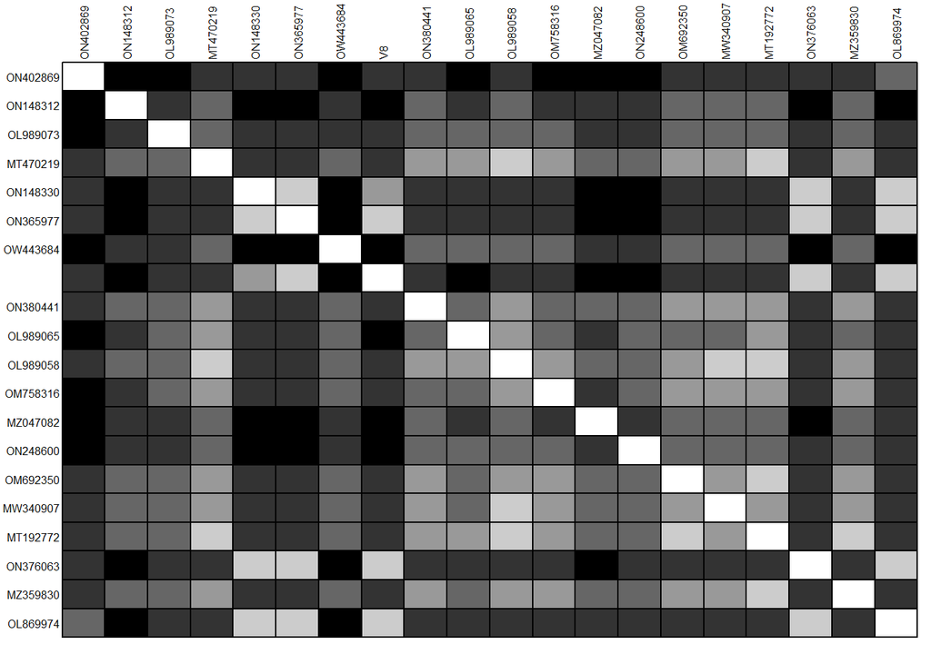

```r
BrowseSeqs(virus_seq_align, highlight=0)

writeXStringSet(virus_seq_align, file="virus_seq_align.fasta")

virus_aligned <- read.alignment("virus_seq_align.fasta", format = "fasta")

matriz_distancia <- dist.alignment(virus_aligned, matrix = "similarity")

temp <- as.data.frame(as.matrix(matriz_distancia))
table.paint(temp, cleg=0, clabel.row=.5, clabel.col=.5) + scale_color_viridis()
```

```r
virus_tree <- nj(matriz_distancia)
class(virus_tree)
```

```
## [1] "phylo"
```

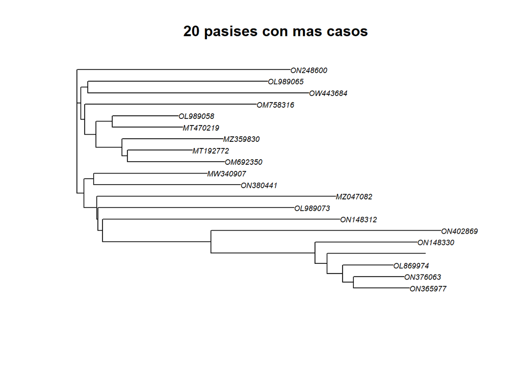

```r
virus_tree <- ladderize(virus_tree)

plot(virus_tree, cex = 0.6)
title("20 pasises con mas casos")
```

## ### Interpretación de gráficas

```r
citation("seqinr")
```

```
##
##
##   Charif, D. and Lobry, J.R. (2007)
##
## A BibTeX entry for LaTeX users is
##
##   @InCollection{,
##     author = {D. Charif and J.R. Lobry},
##     title = {Seqin{R} 1.0-2: a contributed package to the {R} project for statistical computing devoted to biological sequences retrieval and analysis.},
##     booktitle = {Structural approaches to sequence evolution: Molecules, networks, populations},
##     year = {2007},
##     editor = {U. Bastolla and M. Porto and H.E. Roman and M. Vendruscolo},
##     series = {Biological and Medical Physics, Biomedical Engineering},
##     pages = {207-232},
##     address = {New York},
##     publisher = {Springer Verlag},
##     note = {{ISBN :} 978-3-540-35305-8},
##   }
```

```r
citation("dplyr")
```

```
##
##
##   Hadley Wickham, Romain François, Lionel Henry and Kirill Müller (2022). dplyr: A
##   Grammar of Data Manipulation. R package version 1.0.9.
##   https://CRAN.R-project.org/package=dplyr
##
## A BibTeX entry for LaTeX users is
##
##   @Manual{,
##     title = {dplyr: A Grammar of Data Manipulation},
##     author = {Hadley Wickham and Romain François and Lionel Henry and Kirill Müller},
##     year = {2022},
##     note = {R package version 1.0.9},
##     url = {https://CRAN.R-project.org/package=dplyr},
##   }
```

```r
citation("ape")
```

```
##
##
##   Paradis E. & Schliep K. 2019. ape 5.0: an environment for modern phylogenetics and
##   evolutionary analyses in R. Bioinformatics 35: 526-528.
##
## A BibTeX entry for LaTeX users is
##
##   @Article{,
##     title = {ape 5.0: an environment for modern phylogenetics and evolutionary analyses in {R}},
##     author = {E. Paradis and K. Schliep},
##     journal = {Bioinformatics},
##     year = {2019},
##     volume = {35},
##     pages = {526-528},
##   }
##
## As ape is evolving quickly, you may want to cite also its version number (found with
## 'library(help = ape)' or 'packageVersion("ape")').
```

```r
citation("phangorn")
```

```
##
## Use 2011 to cite phangorn in a publication; 2017 for plotting phylogenetic networks.
## As phangorn is evolving quickly, you may want to cite also its version number
## (phangorn 2.8.1).
##
##   Schliep K.P. 2011. phangorn: phylogenetic analysis in R. Bioinformatics, 27(4)
##   592-593
##
##   Schliep, K., Potts, A. J., Morrison, D. A., Grimm, G. W. (2017), Intertwining
##   phylogenetic trees and networks. Methods in Ecology and Evolution, 8: 1212--1220.
##   doi: 10.1111/2041-210X.12760
##
## To see these entries in BibTeX format, use 'print(<citation>, bibtex=TRUE)',
## 'toBibtex(.)', or set 'options(citation.bibtex.max=999)'.
```

```r
citation("phytools")
```

```
##
##
##   Revell, L. J. (2012) phytools: An R package for phylogenetic comparative biology
##   (and other things). Methods Ecol. Evol. 3 217-223.
##   doi:10.1111/j.2041-210X.2011.00169.x
##
## A BibTeX entry for LaTeX users is
##
##   @Article{,
##     title = {phytools: An R package for phylogenetic comparative biology (and other things).},
##     author = {Liam J. Revell},
##     journal = {Methods in Ecology and Evolution},
##     year = {2012},
##     volume = {3},
##     pages = {217-223},
##   }
##
## As phytools is continually evolving, you may want to cite its version number. Find
## it with 'help(package=phytools)'.
```

```r
citation("geiger")
```

```
##
##
## medusa
##
##   Alfaro Michael E, Francesco Santini, Chad Brock, Hugo Alamillo, Alex Dornburg,
##   Daniel L Rabosky, Giorgio Carnevale, and Luke J Harmon. 2009. Nine exceptional
##   radiations plus high turnover explain species diversity in jawed vertebrates. PNAS
##   106:13410-13414.
##
## auteur
##
##   Eastman Jonathan M, Michael E Alfaro, Paul Joyce, Andrew L Hipp, and Luke J
##   Harmon. 2011. A novel comparative method for identifying shifts in the rate of
##   character evolution on trees. Evolution 65:3578-3589.
##
## MECCA
##
##   Slater Graham J, Luke J Harmon, Daniel Wegmann, Paul Joyce, Liam J Revell, and
##   Michael E Alfaro. 2012. Fitting models of continuous trait evolution to
##   incompletely sampled comparative data using approximate Bayesian computation.
##   Evolution 66:752-762.
##
## geiger-orig
##
##   Harmon Luke J, Jason T Weir, Chad D Brock, Richard E Glor, and Wendell Challenger.
##   2008. GEIGER: investigating evolutionary radiations. Bioinformatics 24:129-131.
##
## geiger
##
##   Pennell Matthew W, Jonathan M Eastman, Graham J Slater, Joseph W Brown, Josef C
##   Uyeda, Richard G FitzJohn, Michael E Alfaro, and Luke J Harmon. 2014. geiger v2.0:
##   an expanded suite of methods for fitting macroevolutionary models to phylogenetic
##   trees. Bioinformatics 30:2216-2218.
##
## To see these entries in BibTeX format, use 'print(<citation>, bibtex=TRUE)',
## 'toBibtex(.)', or set 'options(citation.bibtex.max=999)'.
```

```r
citation("ggmsa")
```

```
##
##
##   Lang Zhou and Guangchuang Yu (2021). ggmsa: Plot Multiple Sequence Alignment using
##   'ggplot2'. R package version 1.0.0. http://yulab-smu.top/ggmsa/
##
## A BibTeX entry for LaTeX users is
##
##   @Manual{,
##     title = {ggmsa: Plot Multiple Sequence Alignment using 'ggplot2'},
##     author = {Lang Zhou and Guangchuang Yu},
##     year = {2021},
##     note = {R package version 1.0.0},
##     url = {http://yulab-smu.top/ggmsa/},
##   }
```

NCBI. (s. f.). NCBI - Virus. https://www.ncbi.nlm.nih.gov/labs/virus/vssi/#/

Location/Qualifiers source 1..29705 /organism=“Severe acute respiratory syndrome coronavirus 2” /mol_type=“genomic RNA” /isolate=“SARS-CoV-2/human/AUS/A12-WW-209C/2021” /isolation_source=“wastewater” /host=“Homo sapiens” /db_xref=“taxon:2697049” /country=“Australia” /collection_date=“2021-11-25” /collected_by=“CSIRO Australia”

source 1..29800 /organism=“Severe acute respiratory syndrome coronavirus 2” /mol_type=“genomic RNA” /isolate=“SARS-CoV-2/human/IRN/12624/2020” /isolation_source=“throat swab” /host=“Homo sapiens” /db_xref=“taxon:2697049” /country=“Iran” /collection_date=“2020-04-28”

source 1..29747 /organism=“Severe acute respiratory syndrome coronavirus 2” /mol_type=“genomic RNA” /isolate=“SARS-CoV-2/human/JPN/HiroFH232c/2022” /isolation_source=“saliva” /host=“Homo sapiens” /db_xref=“taxon:2697049” /country=“Japan” /collection_date=“2022-01-04”

source 1..29813 /organism=“Severe acute respiratory syndrome coronavirus 2” /mol_type=“genomic RNA” /isolate=“SARS-CoV-2/human/TUR/DENIZLI_PAU_07/2020” /isolation_source=“nasal swab” /host=“Homo sapiens” /db_xref=“taxon:2697049” /country=“Turkey” /collection_date=“2020-07-18”

source 1..29848 /organism=“Severe acute respiratory syndrome coronavirus 2” /mol_type=“genomic RNA” /isolate=“SARS-CoV-2/human/KOR/KCDC03-NCCP43326/2021” /isolation_source=“throat swab” /host=“Homo sapiens” /db_xref=“taxon:2697049” /country=“South Korea” /collection_date=“2021-02-24”

source 1..29816 /organism=“Severe acute respiratory syndrome coronavirus 2” /mol_type=“genomic RNA” /isolate=“SARS-CoV- 2/Canine/IND/A4N_Dog_Gujarat_India/2021” /isolation_source=“nasal swab” /host=“canine” /db_xref=“taxon:2697049” /country=“India” /collection_date=“2021-05-26” /collected_by=“Dr. Arun C. Patel”

source 1..29884 /organism=“Severe acute respiratory syndrome coronavirus 2” /mol_type=“genomic RNA” /isolate=“SARS-CoV-2/human/POL/IHG_PAS_25_P7908/2020” /isolation_source=“oronasopharynx” /host=“Homo sapiens” /db_xref=“taxon:2697049” /country=“Poland” /collection_date=“2020-03-15”

source 1..29833 /organism=“Severe acute respiratory syndrome coronavirus 2” /mol_type=“genomic RNA” /isolate=“SARS-CoV-2/Neovison vison/NLD/NB68-08/2020” /isolation_source=“throat swab” /host=“Neogale vison” /db_xref=“taxon:2697049” /country=“Netherlands” /collection_date=“2020-11-03”

source 1..29903 /organism=“Severe acute respiratory syndrome coronavirus 2” /mol_type=“genomic RNA” /isolate=“SARS-CoV-2/human/ESP/200324-28/2020” /isolation_source=“throat swabs” /host=“Homo sapiens;Male,age 18” /db_xref=“taxon:2697049” /country=“Spain” /collection_date=“2020-03-16”

source 1..29903 /organism=“Severe acute respiratory syndrome coronavirus 2” /mol_type=“genomic RNA” /isolate=“SARS-CoV-2/human/ITA/201109-49/2020” /isolation_source=“throat swabs” /host=“Homo sapiens;Female,age 51” /db_xref=“taxon:2697049” /country=“Italy” /collection_date=“2020-10-27”